# Data Quality and Readiness Assessment

ML-Assisted Screening for Systematic Reviews

Author

Heather Copley, Jarret Glass, Andras Paul

# Purpose

This document describes data quality checks and basic descriptive summaries performed on bibliographic data sets to be used for machine-learning–assisted screening in a systematic review.

The purpose of this assessment is to confirm that:

- The data are complete and internally consistent
- Screening labels are well defined
- Text fields are usable for modeling
- Training and prediction data sets are comparable

This document focuses on data readiness and does not include modeling.

# Summary of Findings

# Data Sources

## Prediction Dataset

# High-Level Descriptive Overview

This section provides a quick, standardized summary of each data set, including variable types, missingness, and basic distributions. These summaries are descriptive and do not replace rule-based checks later in the document.

## Training Dataset Overview

|  | skim_type | skim_variable | n_missing | complete_rate | character.min | character.max | character.empty | character.n_unique | character.whitespace | logical.mean | logical.count | numeric.mean | numeric.sd | numeric.p0 | numeric.p25 | numeric.p50 | numeric.p75 | numeric.p100 | numeric.hist |
| --- | --- | --- | --- | --- | --- | --- | --- | --- | --- | --- | --- | --- | --- | --- | --- | --- | --- | --- | --- |
| 1 | character | src | 0 | 1 | 2 | 2 | 0 | 8 | 0 |  |  |  |  |  |  |  |  |  |  |
| 2 | character | pubtype | 2 | 0.9999592701205604 | 1 | 18 | 0 | 20 | 0 |  |  |  |  |  |  |  |  |  |  |
| 3 | character | authors | 1575 | 0.967925219941349 | 4 | 2018 | 0 | 44918 | 0 |  |  |  |  |  |  |  |  |  |  |
| 4 | character | editor | 48319 | 0.01598647768002603 | 8 | 255 | 0 | 478 | 0 |  |  |  |  |  |  |  |  |  |  |
| 5 | character | year | 1 | 0.9999796350602802 | 4 | 65 | 0 | 1864 | 0 |  |  |  |  |  |  |  |  |  |  |
| 6 | character | date | 22259 | 0.5466968067774519 | 3 | 17 | 0 | 4462 | 0 |  |  |  |  |  |  |  |  |  |  |
| 7 | character | title | 0 | 1 | 4 | 469 | 0 | 47649 | 0 |  |  |  |  |  |  |  |  |  |  |
| 8 | character | title2 | 48076 | 0.02093515803193224 | 4 | 253 | 0 | 730 | 0 |  |  |  |  |  |  |  |  |  |  |
| 9 | character | series | 48600 | 0.01026392961876832 | 11 | 231 | 0 | 342 | 0 |  |  |  |  |  |  |  |  |  |  |
| 10 | character | journal | 1536 | 0.9687194525904204 | 2 | 100 | 0 | 6617 | 0 |  |  |  |  |  |  |  |  |  |  |

[output cut: 30 more lines]

- The training data has several columns with <10% complete rate. We can safely remove these.
- Abstracts in the training set have up to 9994 characters.
- There are 4455 missing abstracts in the training dataset.
- There are less unique abstracts and titles than there are records. This indicates some duplicates exist in the training data.

## Prediction Dataset Overview

|  | skim_type | skim_variable | n_missing | complete_rate | character.min | character.max | character.empty | character.n_unique | character.whitespace | numeric.mean | numeric.sd | numeric.p0 | numeric.p25 | numeric.p50 | numeric.p75 | numeric.p100 | numeric.hist |
| --- | --- | --- | --- | --- | --- | --- | --- | --- | --- | --- | --- | --- | --- | --- | --- | --- | --- |
| 1 | character | label | 0 | 1 | 8 | 200 | 0 | 40570 | 0 |  |  |  |  |  |  |  |  |
| 2 | character | type | 0 | 1 | 3 | 4 | 0 | 10 | 0 |  |  |  |  |  |  |  |  |
| 3 | character | abstract | 2486 | 0.9391074315387253 | 1 | 25504 | 0 | 35371 | 0 |  |  |  |  |  |  |  |  |
| 4 | character | accession | 0 | 1 | 8 | 25 | 0 | 37701 | 0 |  |  |  |  |  |  |  |  |
| 5 | character | author | 990 | 0.9757507470729437 | 4 | 3765 | 0 | 35672 | 0 |  |  |  |  |  |  |  |  |
| 6 | character | doi | 4314 | 0.8943320433057366 | 3 | 57 | 0 | 33394 | 0 |  |  |  |  |  |  |  |  |
| 7 | character | pages | 2109 | 0.9483417430069073 | 1 | 21 | 0 | 17667 | 0 |  |  |  |  |  |  |  |  |
| 8 | character | issue | 11729 | 0.7127075883015725 | 1 | 42 | 0 | 414 | 0 |  |  |  |  |  |  |  |  |
| 9 | character | journal | 145 | 0.9964483417430069 | 3 | 221 | 0 | 6327 | 0 |  |  |  |  |  |  |  |  |
| 10 | character | keywords | 2013 | 0.9506931857149855 | 5 | 2244 | 0 | 35677 | 0 |  |  |  |  |  |  |  |  |

[output cut: 13 more lines]

- The lowest complete rate is 0.38 for the prediction data the other columns are mostly complete.
- There are 4314 that are missing DOIs in the prediction data set.
- Abstracts in the prediction set have up to 25504 characters.
- There are 2486 missing abstracts in the prediction data set.

# Record-Level Integrity Checks

## Unique Identifiers

|  | dataset | n_rows | n_unique_ids | n_missing | n_duplicates |
| --- | --- | --- | --- | --- | --- |
| 1 | training | 49104 | 49104 | 0 | 0 |
| 2 | prediction | 40826 | 33394 | 4314 | 7431 |

- DOIs are not unique in the prediction data set there are 7431 duplicate DOIs. We will want to de-duplicate at least first by DOI and possibly later my string distinct methods on titles and abstracts.
- There are 4314 missing DOIs in the prediction data set. We may want to consider another unique identifier, or drop these records.

## Duplicate Indicators

We believe the training data was de-duplicated and the later a unique index was assigned to each record. We can check whether there are unexpected duplicates using some fields that should theoretically be unique such as DOI. Duplicate DOIs could represent different version updates, corrections or retractions of the same article, truncation, or simply data errors, but we should investigate these further.

|  | doi | num_duplicates |
| --- | --- | --- |
| 1 | 10.1007/s00787-010-0117-5 | 26 |
| 2 | 10.1002/mhw | 10 |
| 3 | 10.1007/s00787-006-0571-2 | 4 |
| 4 | 10.1080/00048670902721095 | 4 |
| 5 | 10.1089/jwh.2007.0635 | 4 |
| 6 | 10.1111/cch.12168 | 4 |
| 7 | 10.1136/bmj.326.7397.1008 | 4 |
| 8 | 10.1177/0004867414538675 | 4 |
| 9 | 10.1001/archpsyc.63.8.865 | 3 |
| 10 | 10.1001/jama.2013.2270 | 3 |

There are 1886 duplicate DOIs in the training data set. There are 2 ouliers that are duplicated 10 or more times. Some examples are shown above. We will look at these more closely below.

|  | doi | title | abstract | journal | date |
| --- | --- | --- | --- | --- | --- |
| 1 | 10.1007/s00787-010-0117-5 | Translational science in ADHD. | Copyright of European Child &amp; Adolescent Psychiatry is the property of Springer Science &amp; Business Media B.V. and its content may not be copied or emailed to multiple sites or posted to a list… | European Child &amp; Adolescent Psychiatry |  |
| 2 | 10.1007/s00787-010-0117-5 | The danger of drugs. | Copyright of European Child &amp; Adolescent Psychiatry is the property of Springer Science &amp; Business Media B.V. and its content may not be copied or emailed to multiple sites or posted to a list… | European Child &amp; Adolescent Psychiatry |  |
| 3 | 10.1007/s00787-010-0117-5 | Therapeutic use of stimulants in ADHD. | Copyright of European Child &amp; Adolescent Psychiatry is the property of Springer Science &amp; Business Media B.V. and its content may not be copied or emailed to multiple sites or posted to a list… | European Child &amp; Adolescent Psychiatry |  |
| 4 | 10.1007/s00787-010-0117-5 | Neuropsychological performance and the validity of DSM-IV ADHD subtypes. | Copyright of European Child &amp; Adolescent Psychiatry is the property of Springer Science &amp; Business Media B.V. and its content may not be copied or emailed to multiple sites or posted to a list… | European Child &amp; Adolescent Psychiatry |  |
| 5 | 10.1007/s00787-010-0117-5 | Understanding the universal burden of adult ADHD: a seven country perspective. | Copyright of European Child &amp; Adolescent Psychiatry is the property of Springer Science &amp; Business Media B.V. and its content may not be copied or emailed to multiple sites or posted to a list… | European Child &amp; Adolescent Psychiatry |  |
| 6 | 10.1007/s00787-010-0117-5 | Somatic conditions beyond core symptoms: is ADHD a multifaceted medical condition? | Copyright of European Child &amp; Adolescent Psychiatry is the property of Springer Science &amp; Business Media B.V. and its content may not be copied or emailed to multiple sites or posted to a list… | European Child &amp; Adolescent Psychiatry |  |
| 7 | 10.1007/s00787-010-0117-5 | Active pharmacovigilance in developmental neuropsychiatry: the Italian ADHD National Registry. | Copyright of European Child &amp; Adolescent Psychiatry is the property of Springer Science &amp; Business Media B.V. and its content may not be copied or emailed to multiple sites or posted to a list… | European Child &amp; Adolescent Psychiatry |  |
| 8 | 10.1007/s00787-010-0117-5 | ADHD, obesity: an Italian clinical sample. | Copyright of European Child &amp; Adolescent Psychiatry is the property of Springer Science &amp; Business Media B.V. and its content may not be copied or emailed to multiple sites or posted to a list… | European Child &amp; Adolescent Psychiatry |  |
| 9 | 10.1007/s00787-010-0117-5 | Error and feedback processing in children with ADHD and children with autistic spectrum disorder: an EEG event-related potential study. | Copyright of European Child &amp; Adolescent Psychiatry is the property of Springer Science &amp; Business Media B.V. and its content may not be copied or emailed to multiple sites or posted to a list… | European Child &amp; Adolescent Psychiatry |  |
| 10 | 10.1007/s00787-010-0117-5 | Methylphenidate improves diminished error and feedback sensitivity in ADHD: an evoked heart rate analysis. | Copyright of European Child &amp; Adolescent Psychiatry is the property of Springer Science &amp; Business Media B.V. and its content may not be copied or emailed to multiple sites or posted to a list… | European Child &amp; Adolescent Psychiatry |  |

[output cut: 16 more lines]

The doi that is replicated the most often is 10.1007/s00787-010-0117-5 with 26 duplicates. Looking at the titles and abstracts seems to confirm that these are in fact different articles, however some of the abstracts are filled with copyright language rather than the actual abstract.

|  | doi | title | abstract | journal | date |
| --- | --- | --- | --- | --- | --- |
| 1 | 10.1002/mhw | Medicaid oversight of antipsychotic use in children examined in 31 states. |  | Mental Health Weekly |  |
| 2 | 10.1002/mhw | Study finds most young people treated with antipsychotics lack MH diagnosis. |  | Mental Health Weekly |  |
| 3 | 10.1002/mhw | Study finds most young people treated with antipsychotics lack MH diagnosis. (cover story) | The article offers information on a study titled "Treatment of Young People With Antipsychotic Medications in the United States." Topics include the efficacy of antipsychotics for bipolar mania, adole… | Mental Health Weekly |  |
| 4 | 10.1002/mhw | PCPs, rather than mental health providers, seeing more children with MI. |  | Mental Health Weekly |  |
| 5 | 10.1002/mhw | PCPs, rather than mental health providers, seeing more children with MI. (cover story) | The article discusses the findings of the study "Outpatient Visits and Medication Prescribing for US Children With Mental Health Conditions" by the American Academy of Pediatrics (AAP). The study sugg… | Mental Health Weekly |  |
| 6 | 10.1002/mhw | Nearly 8 percent of school-age children on mental health medications. (cover story) | This article discusses findings of a report from the U.S. Centers for Disease Control and Prevention (CDC) on the use of medication prescribed for emotional or behavioral difficulties among school-age… | Mental Health Weekly |  |
| 7 | 10.1002/mhw | Antipsychotic treatment in children linked with diabetes risk. |  | Mental Health Weekly |  |
| 8 | 10.1002/mhw | New CDC report reveals ongoing increases in children's MH disorders. (cover story) | The article highlights a report issued by the U.S. Centers for Disease Control and Prevention (CDC) on the increasing number of mental health cases in children. The study showed that attention-deficit… | Mental Health Weekly |  |
| 9 | 10.1002/mhw | FDA permits marketing of first brain-wave test to assess ADHD. | The article reports that U.S. Food and Drug Administration (FDA) has allowed the marketing of the first medical device based on brain function on July 15, 2013. The device Neuropsychiatric EEG-Based A… | Mental Health Weekly |  |
| 10 | 10.1002/mhw | AACAP encouraged by AMA recommendation for Rx research. |  | Mental Health Weekly |  |

The doi that is replicated the 2nd most frequently is 10.1002/mhw with 10 duplicates. A few of these do look to be duplicates, but the majority are not, and removing records that have no abstract would resolve this issue in this case.

For the remainder however These appear to be mostly duplicated records with some minor variations in titles or abstracts though removing records with missing abstracts would take care of a small percentage of these records.

|  | doi | title | abstract | journal | date |
| --- | --- | --- | --- | --- | --- |
| 1 | 10.1001/archgenpsychiatry.2007.40 | Depression in young adults with very low birth weight | Context: Little is known about the mental health outcomes of very low-birth-weight ( VLBW) ( &lt; 1500 g) infants in young adulthood.%%%%%%Objective: To test whether young adults aged 18 to 27 years w… | ARCHIVES OF GENERAL PSYCHIATRY | MAR |
| 2 | 10.1001/archgenpsychiatry.2007.40 | Depression in young adults with very low birth weight: the Helsinki study of very low-birth-weight adults. | Little is known about the mental health outcomes of very low-birth-weight (VLBW) (&lt; 1500 g) infants in young adulthood. | Archives of general psychiatry | 2008/Mar/ |
| 3 | 10.1001/archgenpsychiatry.2007.43 | Protein kinase C inhibition in the treatment of mania | Context: Findings that protein kinase C ( PKC) activity may be altered in mania, and that both lithium carbonate and valproate sodium inhibit PKC-associated signaling in brain tissue, encourage develo… | ARCHIVES OF GENERAL PSYCHIATRY | MAR |
| 4 | 10.1001/archgenpsychiatry.2007.43 | Protein kinase C inhibition in the treatment of mania: a double-blind, placebo-controlled trial of tamoxifen. | Findings that protein kinase C (PKC) activity may be altered in mania, and that both lithium carbonate and valproate sodium inhibit PKC-associated signaling in brain tissue, encourage development of P… | Archives of general psychiatry | 2008/Mar/ |
| 5 | 10.1001/archgenpsychiatry.2012.647 | Study examines office-based antipsychotic prescribing in youth. |  | Brown University Child &amp; Adolescent Psychopharmacology Update |  |
| 6 | 10.1001/archgenpsychiatry.2012.647 | National Trends in the Office-Based Treatment of Children, Adolescents, and Adults With Antipsychotics | Context: Although antipsychotic treatment has recently increased, little is known about how this development has differentially affected the office-based care of adults and young people in the United … | ARCHIVES OF GENERAL PSYCHIATRY | DEC |
| 7 | 10.1001/archpedi.157.10.984 | Depression in medicaid-covered youth - Differences by race and ethnicity | Background: Racial disparities have previously been noted in antidepressant use. among Medicaid-covered youth.%%%%%%Objective: To determine if racial and ethnic differences are due to dissimilarity in… | ARCHIVES OF PEDIATRICS &amp; ADOLESCENT MEDICINE | OCT |
| 8 | 10.1001/archpedi.157.10.984 | Depression in Medicaid-covered youth: differences by race and ethnicity. | Racial disparities have previously been noted in antidepressant use among Medicaid-covered youth. | Archives of pediatrics &amp; adolescent medicine | 2003/Oct/ |
| 9 | 10.1001/archpsyc.60.8.817 | Depression with atypical features in the national comorbidity survey - Classification, description, and consequences | Background: Atypical depression has been found to be distinct from other types of depression in terms of psychiatric symptom profile and treatment response. However, debate continues regarding its spe… | ARCHIVES OF GENERAL PSYCHIATRY | AUG |
| 10 | 10.1001/archpsyc.60.8.817 | Depression With Atypical Features in the National Comorbidity Survey: Classification, Description, and Consequences. | Examines the diagnosis of atypical depression using only the reversed vegetative symptoms of hypersomnia and hyperphagia. An atypical depression group (n=304) was identified within the US National Com… | Archives of General Psychiatry |  |

# Required Fields Check

This section verifies that required fields exist and are populated. Detailed summaries of missingness are provided above; this section focuses on explicit checks.

|  | dataset | pct_missing_title | pct_missing_abstract | pct_missing_year |
| --- | --- | --- | --- | --- |
| 1 | training | 0 | 0.0907258064516129 | 2.036493971977843e-05 |
| 2 | prediction | 0 | 0.06089256846127468 | 0 |

There are no missing titles in either data set. The training data set has 9.07% missing abstracts while the prediction data set has 6.09% missing abstracts. Both data sets have nearly complete year information.

# Text Field Quality

## Text Fields Overview

This summary focuses specifically on the title and abstract fields.

### Training Data Text Field Summary

|  | skim_type | skim_variable | n_missing | complete_rate | character.min | character.max | character.empty | character.n_unique | character.whitespace |
| --- | --- | --- | --- | --- | --- | --- | --- | --- | --- |
| 1 | character | title | 0 | 1 | 4 | 469 | 0 | 47649 | 0 |
| 2 | character | abstract | 4455 | 0.9092741935483871 | 16 | 9994 | 0 | 43453 | 0 |

### New Data Text Field Summary

|  | skim_type | skim_variable | n_missing | complete_rate | character.min | character.max | character.empty | character.n_unique | character.whitespace |
| --- | --- | --- | --- | --- | --- | --- | --- | --- | --- |
| 1 | character | title | 0 | 1 | 3 | 624 | 0 | 36992 | 0 |
| 2 | character | abstract | 2486 | 0.9391074315387253 | 1 | 25504 | 0 | 35371 | 0 |

## Boilerplate or Placeholder Abstracts

Abstracts that are identical across multiple records may indicate boilerplate text that would not be useful in modeling.

|  | abstract | num_duplicates |
| --- | --- | --- |
| 1 | copyright of european child &amp; adolescent psychiatry is the property of springer science &amp; business media b.v. and its content may not be copied or emailed to multiple sites or posted to a list… | 87 |
| 2 | copyright of pediatrics is the property of american academy of pediatrics and its content may not be copied or emailed to multiple sites or posted to a listserv without the copyright holder's express … | 73 |
| 3 | copyright of australian &amp; new zealand journal of psychiatry is the property of sage publications, ltd. and its content may not be copied or emailed to multiple sites or posted to a listserv withou… | 51 |
| 4 | copyright of pediatric anesthesia is the property of wiley-blackwell and its content may not be copied or emailed to multiple sites or posted to a listserv without the copyright holder's express writt… | 49 |
| 5 | copyright of canadian journal of psychiatry is the property of canadian psychiatric association and its content may not be copied or emailed to multiple sites or posted to a listserv without the copyr… | 45 |
| 6 | copyright of journal of psychopharmacology is the property of sage publications, ltd. and its content may not be copied or emailed to multiple sites or posted to a listserv without the copyright holde… | 35 |
| 7 | copyright of addiction is the property of wiley-blackwell and its content may not be copied or emailed to multiple sites or posted to a listserv without the copyright holder's express written permissi… | 24 |
| 8 | copyright of clinical pediatrics is the property of sage publications inc. and its content may not be copied or emailed to multiple sites or posted to a listserv without the copyright holder's express… | 24 |
| 9 | copyright of british journal of clinical pharmacology is the property of wiley-blackwell and its content may not be copied or emailed to multiple sites or posted to a listserv without the copyright ho… | 22 |
| 10 | copyright of acta paediatrica is the property of wiley-blackwell and its content may not be copied or emailed to multiple sites or posted to a listserv without the copyright holder's express written p… | 21 |

[output cut: 39 more lines]

The abstracts that are repeated more that 5 times shown above appear to be boilerplate rather than meaningful abstracts. These may not be useful for modeling and could be removed. There are 845 records with these abstracts in the training data set.

|  | tolower(abstract) | n |
| --- | --- | --- |
| 1 | abstract not available. | 1 |
| 2 | this is the protocol for a review and there is no abstract. the objectives are as follows:the principle objectives will be to assess the efficacy of antiviral therapy commenced in the first three mont… | 1 |
| 3 | this is the protocol for a review and there is no abstract. the objectives are as follows:to assess the effects of therapeutic erythropoietin (epo) compared to standard supportive treatment on death, … | 1 |

Looking explicitly for common boilerplate patterns reveals only 3 records and only one is non-informative. This suggests that boilerplate abstracts are not a major issue in this data set, but copy-write language in the abstract field may still be a concern.

# Label Quality (Training Data Only)

## Label Distribution

|  | recd_screen | n |
| --- | --- | --- |
| 1 | 0 | 47855 |
| 2 | 1 | 1249 |

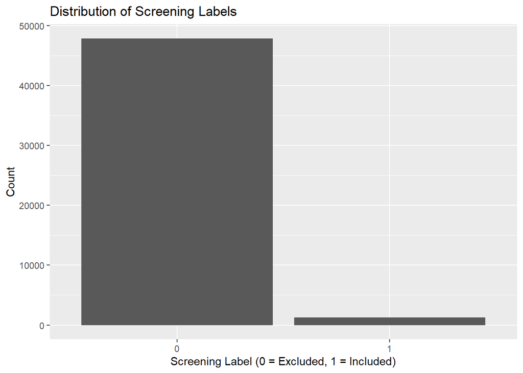

## Label Prevalence by Year

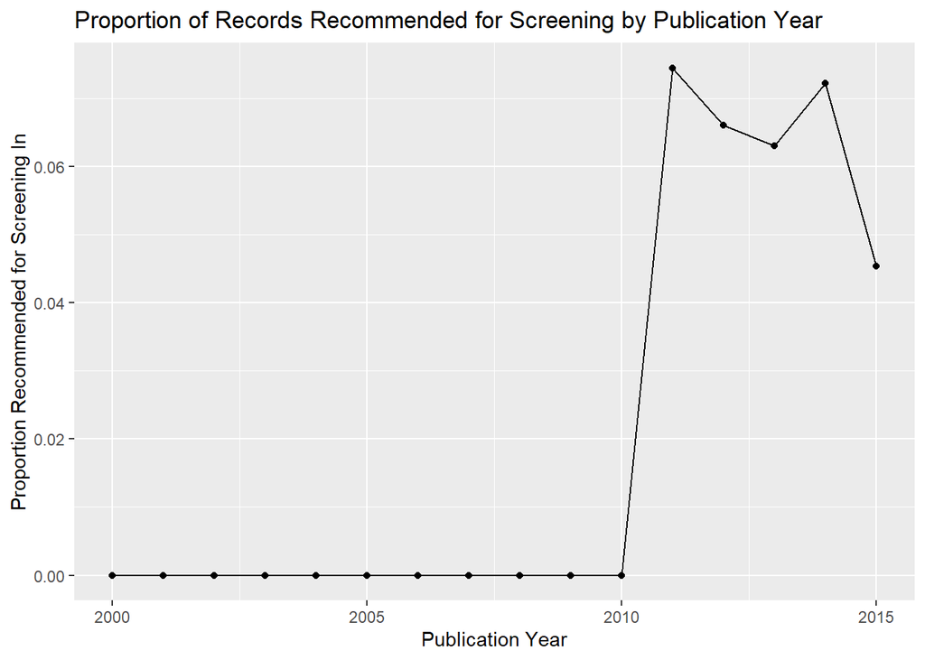

There were no publications recommended for full-text review in years prior to 2011.

## Spot Checks

|  | index | title | abstract |
| --- | --- | --- | --- |
| 1 | 7097 | Racial/ethnic differences in Medicaid expenditures on psychotropic medications among maltreated children | This study quantifies racial/ethnic differences in Medicaid expenditures on psychotropic drugs among a national sample of children with suspected maltreatment. We linked 4,445 child participants in th… |
| 2 | 7811 | Nonadherence to treatment causing acute hospitalizations in people with epilepsy: an observational, prospective study. | The aim was to assess the clinical relevance of antiepileptic drug (AED) nonadherence by means of therapeutic drug concentration monitoring (TDM). Two hundred eighty-two consecutive patients with epil… |
| 3 | 3961 | Antipsychotic Use in Youth Without Psychosis A Double-edged Sword |  |
| 4 | 8970 | DRUG Watch. |  |
| 5 | 4282 | Agitation/Aggression (Acquired Brain Injury): Drug Treatment |  |

# Training vs Prediction Dataset Comparison

This section compares key characteristics of the training and prediction data sets to identify potential differences that may affect modeling.

## Combined Descriptive Summary

|  | skim_type | skim_variable | n_missing | complete_rate | character.min | character.max | character.empty | character.n_unique | character.whitespace | numeric.mean | numeric.sd | numeric.p0 | numeric.p25 | numeric.p50 | numeric.p75 | numeric.p100 | numeric.hist |
| --- | --- | --- | --- | --- | --- | --- | --- | --- | --- | --- | --- | --- | --- | --- | --- | --- | --- |
| 1 | character | dataset | 0 | 1 | 8 | 10 | 0 | 2 | 0 |  |  |  |  |  |  |  |  |
| 2 | character | title | 0 | 1 | 3 | 624 | 0 | 84588 | 0 |  |  |  |  |  |  |  |  |
| 3 | character | journal | 1681 | 0.9813076837540309 | 2 | 221 | 0 | 11153 | 0 |  |  |  |  |  |  |  |  |
| 4 | character | volume | 5200 | 0.9421772489714222 | 1 | 26 | 0 | 1057 | 0 |  |  |  |  |  |  |  |  |
| 5 | character | publisher | 34669 | 0.614489047036584 | 3 | 231 | 0 | 2507 | 0 |  |  |  |  |  |  |  |  |
| 6 | character | url | 10100 | 0.8876904258868008 | 9 | 843 | 0 | 78293 | 0 |  |  |  |  |  |  |  |  |
| 7 | character | doi | 23707 | 0.7363838541087513 | 3 | 75 | 0 | 61029 | 0 |  |  |  |  |  |  |  |  |
| 8 | character | language | 31309 | 0.6518514400088958 | 3 | 9 | 0 | 8 | 0 |  |  |  |  |  |  |  |  |
| 9 | character | abstract | 6941 | 0.9228177471366619 | 1 | 25504 | 0 | 78822 | 0 |  |  |  |  |  |  |  |  |
| 10 | character | keywords | 12329 | 0.8629044812632047 | 5 | 2244 | 0 | 74305 | 0 |  |  |  |  |  |  |  |  |

[output cut: 3 more lines]

## Publication Year Comparison

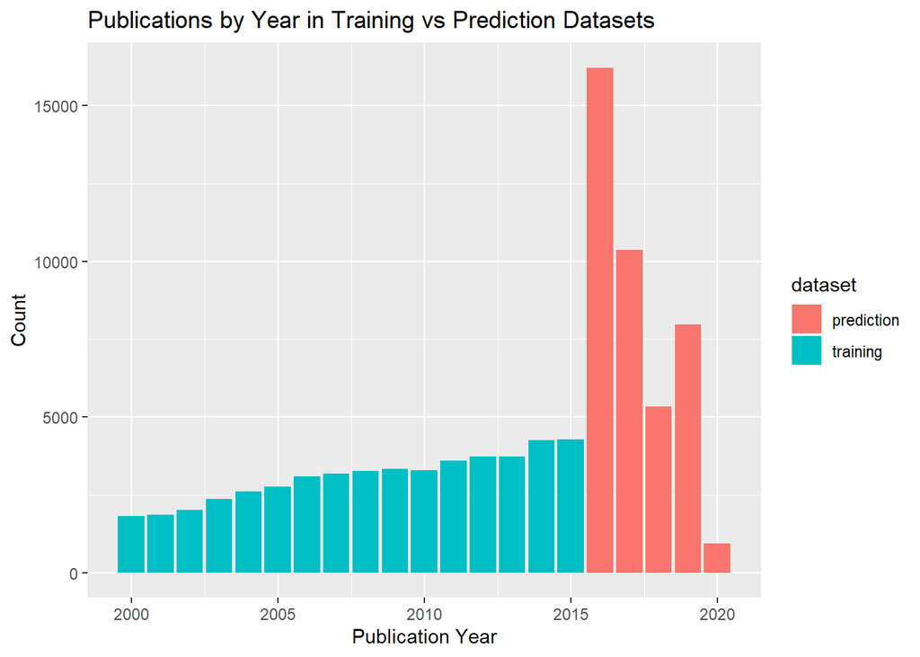

# Modeling Readiness Checks (Non-Modeling)

## Required Fields for Modeling

|  | feature | in_training | in_prediction |
| --- | --- | --- | --- |
| 1 | title | True | True |
| 2 | abstract | True | True |
| 3 | year | True | True |

# Use of Generative AI

Generative AI was used to help draft the initial structure of this Data Readiness Assessment and to act as a thought partner during review, including checking for potential errors or gaps. All substantive decisions, interpretations, and conclusions were made and reviewed by the authors.